# STAT3888 Group 5

2026-09-24

## Cleaned inputs for exploratory checks

The workbooks contain respondent-level records and are used locally. The rendered report shows only aggregate output; the RQ3 models are reproduced from the authorised ABS files as described in Rosetta’s current model and results.

## Confounders

The extended model adjusts for age, sex, energy intake, SEIFA disadvantage, income decile, Year 12 completion, smoking, and alcohol. The core-covariate sensitivity omits income and Year 12 to retain respondents with those fields missing. See Rosetta’s methods for variable definitions and the reason for this comparison.

## Rosetta — fibre, physical activity, and obesity

The single RQ3 model script contains the primary model and every retained sensitivity analysis. It uses the nutrition-cleaned two-day mean intake as primary: NNPAS uses Day 2 weights; NATSINPAS uses its person weights because the Basic CURF has no Day 2-specific weight. The current results and handoff explain the populations and limitations. NNPAS is a general-population sample, **not** a verified non-Indigenous sample. The NATSINPAS activity sample is non-remote. All analyses shown here restrict age to 18–65.

The table reads the single aggregate CSV generated by that script. The first two rows use exactly the same Day 2 completers and replicate weights; only the dietary recall definition changes. The third row expands to all eligible Day 1 respondents.

Adjusted fibre × activity interaction OR (95% CI) using the 150-minute threshold

| Analysis | General NNPAS | Indigenous NATSINPAS (non-remote) |
| --- | --- | --- |
| Day 2 completers, two-day mean — primary | n=3,960; 0.965 (0.857–1.087), p=0.559 | n=408; 0.790 (0.536–1.163), p=0.232 |
| Same Day 2 completers, Day 1 intake | n=3,960; 0.981 (0.883–1.091), p=0.724 | n=408; 0.850 (0.581–1.242), p=0.400 |
| All eligible Day 1 respondents — sensitivity | n=5,863; 0.985 (0.912–1.063), p=0.699 | n=862; 0.967 (0.787–1.189), p=0.751 |

The two-day primary interaction estimates are below 1, but their confidence intervals span 1 in both surveys. The Day 1 sensitivity, the alternative 150-minute-plus-five-session definition and the reduced-confounder check are reported in the consolidated results file and aggregate CSV.

Amelie (robustness): General NNPAS (exploratory, unweighted `eligible_sample`): Boxplots of BMI, waist circumference, and two-day fibre intake. These plots use the cleaned eligible sample rather than the complete-case primary model cohort.

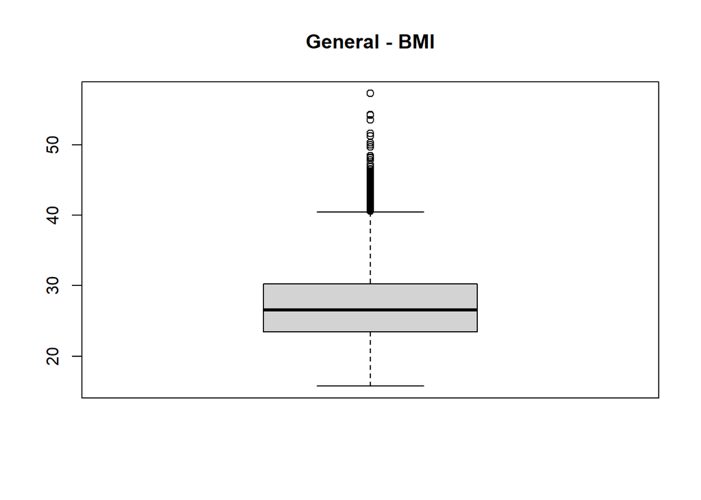

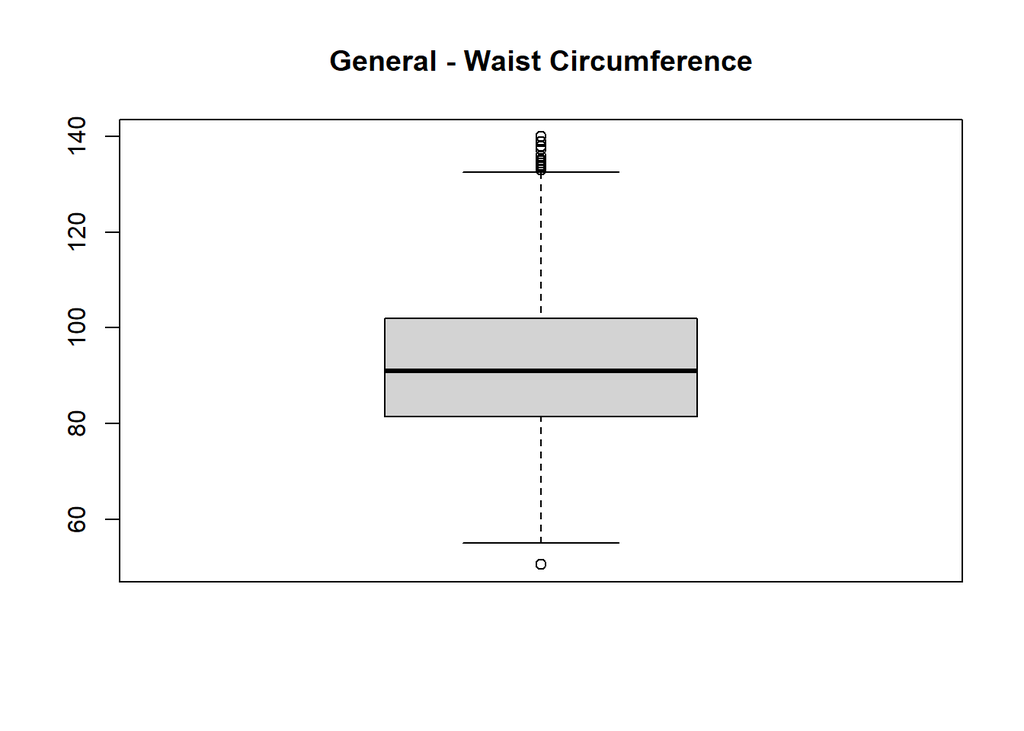

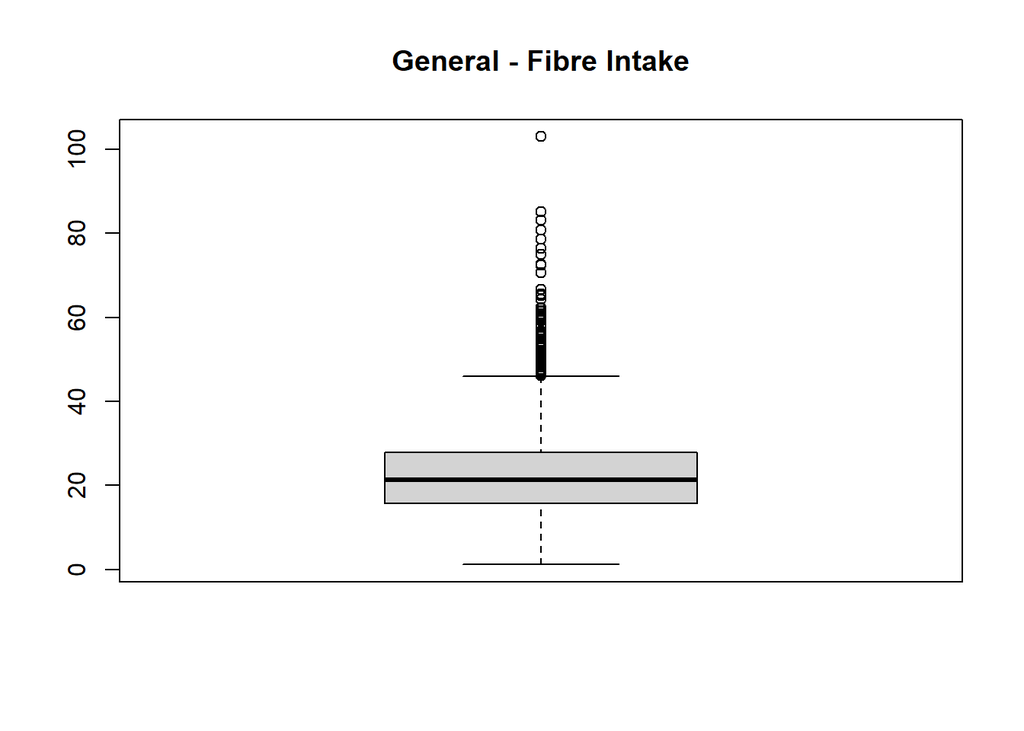

```r
check_outliers <- function(data, name) {
  boxplot(data$bmi, main = paste(name, "- BMI"))
  boxplot(data$waist_cm, main = paste(name, "- Waist Circumference"))
  boxplot(data$fibre_2day_avg_g, main = paste(name, "- Fibre Intake"))
}

check_outliers(general, "General")
```

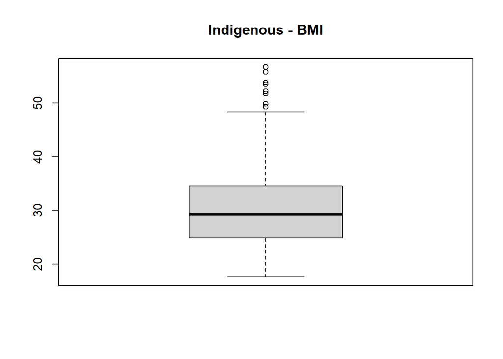

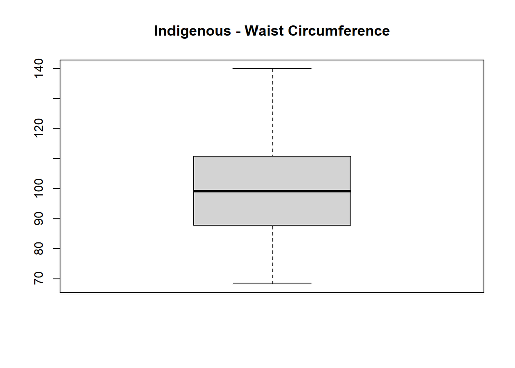

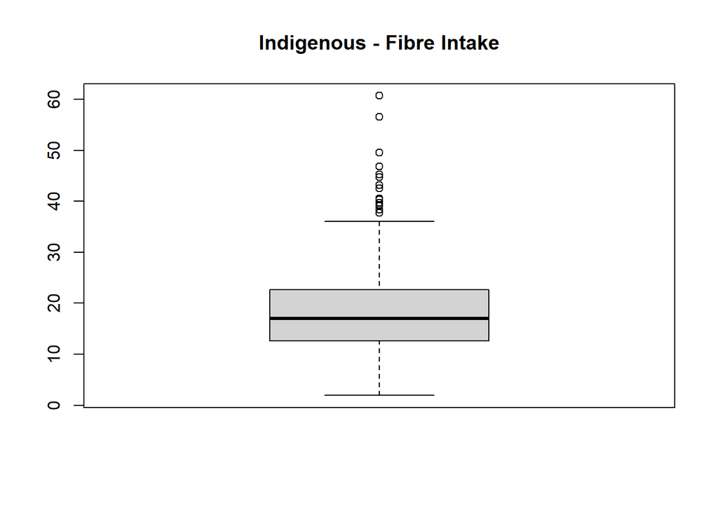

```r
check_outliers(indigenous, "Indigenous")
```

Missing data check (exploratory, on the cleaned `eligible_sample` sheets):

```r
check_missing <- function(data, name) {
  cat("Missingness for", name, ":\n")
  print(colSums(is.na(data)))
  cat("\n")
}

check_missing(general, "General")
```

```
## Missingness for General :
##                      dataset               participant_id
##                            0                            0
##                 household_id                          age
##                            0                            0
##                      sex_raw                          sex
##                            0                            0
##               number_recalls               nutrition_day2
##                            0                            0
##                 fibre_day1_g                 fibre_day2_g
##                            0                            0
##            fibre_food_day1_g            fibre_food_day2_g
##                            0                            0
##      fibre_supplement_day1_g      fibre_supplement_day2_g
##                            0                            0
##             fibre_2day_avg_g                 fibre_per_5g
##                            0                            0
##               energy_day1_kj               energy_day2_kj
##                            0                            0
##           energy_2day_avg_kj               alcohol_day1_g
##                            5                            0
##               alcohol_day2_g           alcohol_2day_avg_g
##                            0                            0
##             pa_guideline_raw                 pa_guideline
##                            0                            0
##      pa_150min_5sessions_raw                 pa_level_raw
##                            0                            0
##                          bmi                     waist_cm
##                            0                           69
##                    obese_bmi            abdominal_obesity
##                            0                           69
##           combined_adiposity           smoking_status_raw
##                           69                            0
##             daily_smoker_raw   sedentary_minutes_week_raw
##                            0                            0
##            sleep_minutes_raw      sleep_typical_night_raw
##                            0                            0
##     self_assessed_health_raw        energy_bmr_ratio_day1
##                            0                            0
##        energy_bmr_ratio_day2         energy_bmr_ratio_avg
```

[output cut: 16 more lines]

```
##                            0                            0
## pa_vigorous_minutes_week_raw       seifa_disadvantage_raw
##                            0                            0
##           seifa_disadvantage            income_decile_raw
##                            0                            0
##                income_decile            qualification_raw
##                          275                            0
##               occupation_raw               remoteness_raw
##                            0                            0
##           marital_status_raw          food_insecurity_raw
##                            0                            0
##                 diabetes_raw        general_person_weight
##                            0                            0
##       selected_survey_weight               weighting_note
##                            0                            0
```

```r
check_missing(indigenous, "Indigenous")
```

```
## Missingness for Indigenous :
##                      dataset               participant_id
##                            0                            0
##                 household_id                          age
##                            0                            0
##                      sex_raw                          sex
##                            0                            0
##               number_recalls               nutrition_day2
##                            0                            0
##                 fibre_day1_g                 fibre_day2_g
##                            0                            0
##            fibre_food_day1_g            fibre_food_day2_g
##                            0                            0
##      fibre_supplement_day1_g      fibre_supplement_day2_g
##                            0                            0
##             fibre_2day_avg_g                 fibre_per_5g
##                            0                            0
##               energy_day1_kj               energy_day2_kj
##                            0                            0
##           energy_2day_avg_kj               alcohol_day1_g
##                            1                            0
##               alcohol_day2_g           alcohol_2day_avg_g
##                            0                            0
##             pa_guideline_raw                 pa_guideline
##                            0                            0
##      pa_150min_5sessions_raw                 pa_level_raw
##                            0                            0
##                          bmi                     waist_cm
##                            0                           21
##                    obese_bmi            abdominal_obesity
##                            0                           21
##           combined_adiposity           smoking_status_raw
##                           21                            0
##             daily_smoker_raw   sedentary_minutes_week_raw
##                            0                            0
##            sleep_minutes_raw      sleep_typical_night_raw
##                            0                            0
##     self_assessed_health_raw        energy_bmr_ratio_day1
##                            0                            0
##        energy_bmr_ratio_day2         energy_bmr_ratio_avg
```

[output cut: 24 more lines]

```
##                            0                            0
##           seifa_disadvantage            income_decile_raw
##                            0                            0
##                income_decile      gross_income_decile_raw
##                           38                            0
##    household_composition_raw         household_adults_raw
##                            0                            0
##       household_children_raw           household_size_raw
##                            0                            0
##               remoteness_raw          food_insecurity_raw
##                            0                            0
## food_insecurity_severity_raw       selected_survey_weight
##                            0                            0
##               weighting_note
##                            0
```

# Gary/Selina (assumptions):

## Decision tree fitted

Tree methods are fast, interpretable ways to fit both regression and classification data.

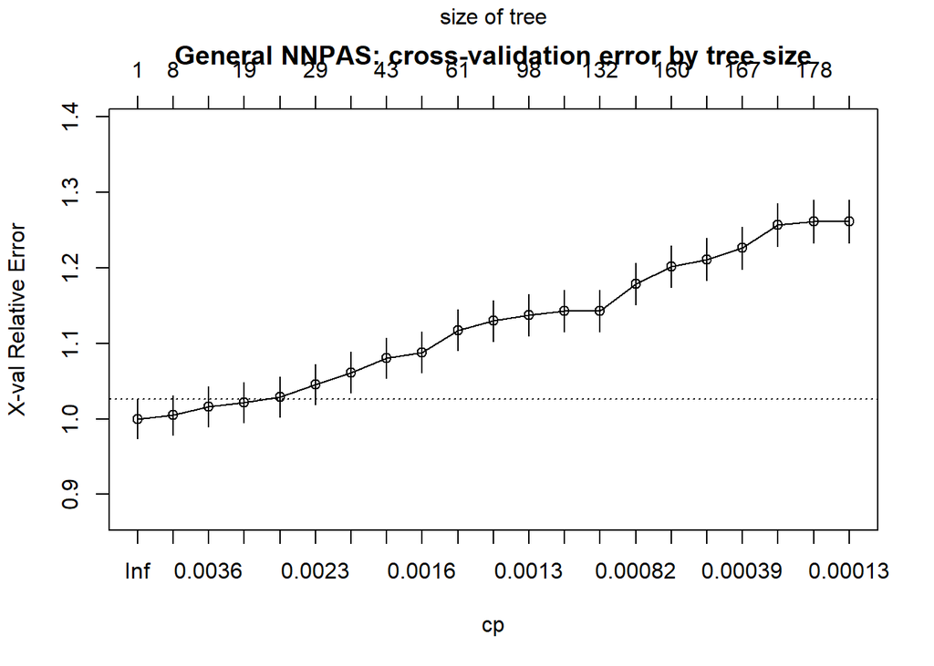

```r
tree_formula <- obesity ~
  fibre5 +
  activity +
  age10 +
  age10_sq +
  sex_factor +
  energy_mj +
  ses +
  income +
  year12_factor +
  smoking +
  alcohol

fit_pruned_tree <- function(df) {
  if (!is.data.frame(df)) {
    stop("fit_pruned_tree() requires a data.frame. Run Sections 1-3 first.")
  }

  required_tree_variables <- all.vars(tree_formula)
  missing_tree_variables <- setdiff(required_tree_variables, names(df))
  if (length(missing_tree_variables)) {
    stop(
      "Tree data are missing: ",
      paste(missing_tree_variables, collapse = ", "),
      ". Run Sections 1-3 before Section 5."
    )
  }

  large_tree <- rpart(
    tree_formula,
    data = df,
    method = "class",
    parms = list(split = "information"),
    control = rpart.control(
      cp = 0.0001,
      minsplit = 20,
      xval = 10
    )
  )

  cp_table <- large_tree$cptable
  best_cp <- cp_table[which.min(cp_table[, "xerror"]), "CP"]

  list(
    large_tree = large_tree,
    pruned_tree = prune(large_tree, cp = best_cp),
    best_cp = best_cp
  )
}

general_tree <- fit_pruned_tree(general_data)

plotcp(
  general_tree$large_tree,
  main = "General NNPAS: cross-validation error by tree size"
)
```

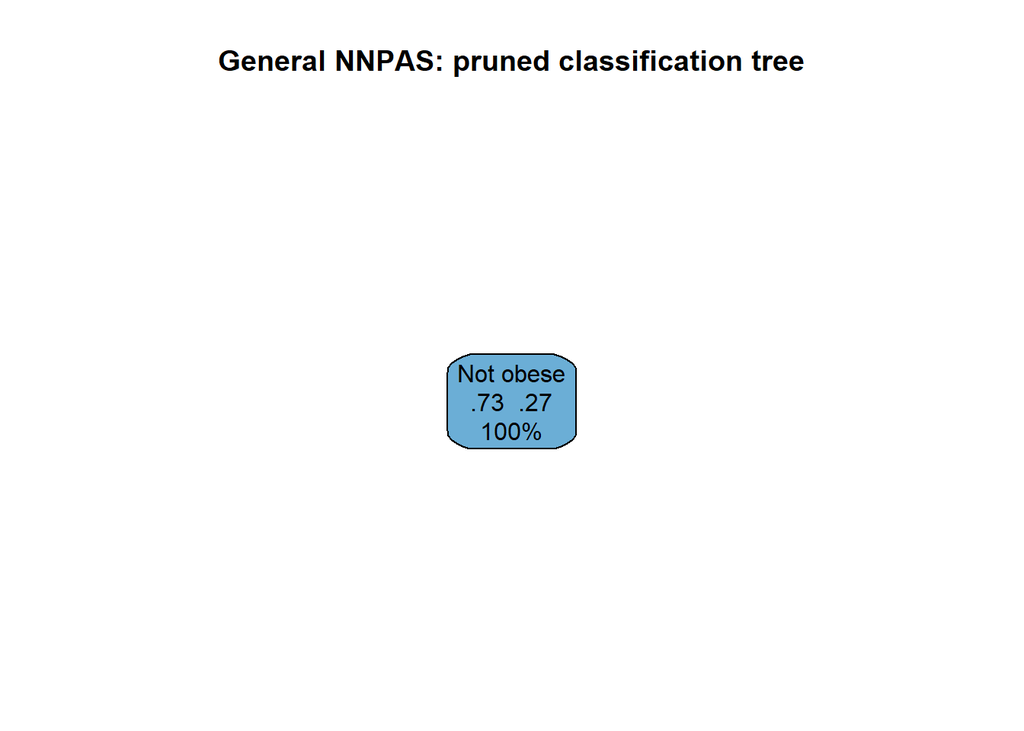

```r
rpart.plot(
  general_tree$pruned_tree,
  type = 4,
  extra = 104,
  fallen.leaves = TRUE,
  main = "General NNPAS: pruned classification tree"
)
```

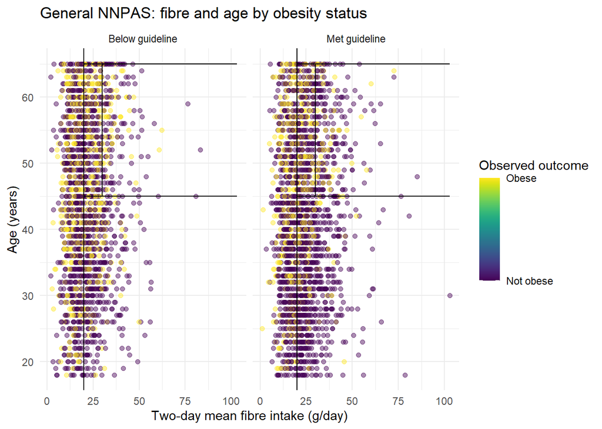

```r
general_tree_scatter <- ggplot(
  general_data,
  aes(
    x = 20 + 5 * fibre5,
    y = 45 + 10 * age10,
    colour = obese
  )
) +
  geom_point(alpha = 0.45, size = 1.6) +
  scale_colour_viridis(
    limits = c(0, 1),
    breaks = c(0, 1),
    labels = c("Not obese", "Obese"),
    name = "Observed outcome"
  ) +
  geom_vline(xintercept = 20) +
  annotate(
    "segment",
    x = 20,
    xend = max(20 + 5 * general_data$fibre5),
    y = 45,
    yend = 45
  ) +
  annotate(
    "segment",
    x = 20,
    xend = max(20 + 5 * general_data$fibre5),
    y = 65,
    yend = 65
  ) +
  annotate(
    "segment",
    x = 30,
    xend = 30,
    y = 45,
    yend = 65
  ) +
  facet_wrap(~activity) +
  labs(
    title = "General NNPAS: fibre and age by obesity status",
    x = "Two-day mean fibre intake (g/day)",
    y = "Age (years)"
  ) +
  theme_minimal()

print(general_tree_scatter)
```

In the General NNPAS chart,the cross-validation relative error was lowest for the smallest decision tree and increased as the tree became more complex. This indicates that adding more splits did not improve out-of-sample predictive performance and instead increased the risk of overfitting.

The scatter plot illustrates the observed relationship between fibre intake, age, physical activity and obesity in the General NNPAS sample. It suggests that the distribution of obese and non-obese participants overlapped considerably across fibre intake and age in both physical-activity groups.

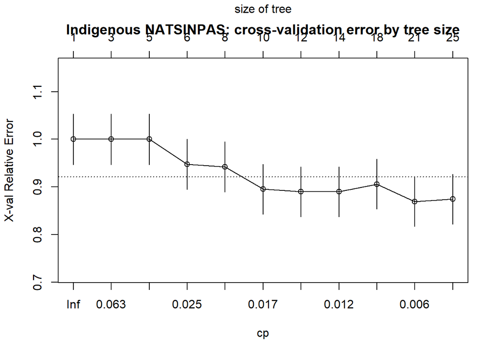

```r
indigenous_tree <- fit_pruned_tree(indigenous_data)

plotcp(
  indigenous_tree$large_tree,
  main = "Indigenous NATSINPAS: cross-validation error by tree size"
)
```

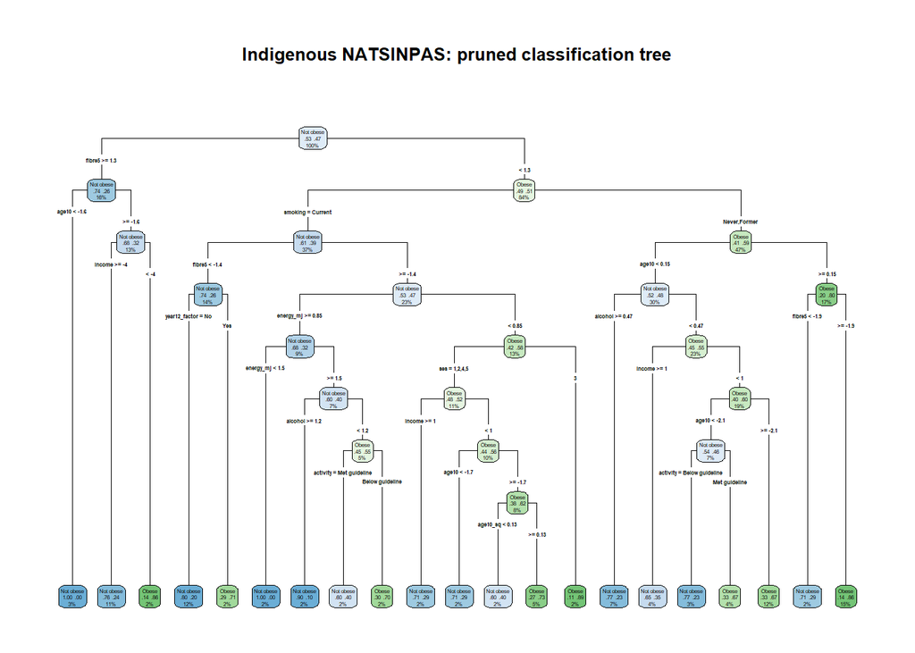

```r
rpart.plot(
  indigenous_tree$pruned_tree,
  type = 4,
  extra = 104,
  fallen.leaves = TRUE,
  main = "Indigenous NATSINPAS: pruned classification tree"
)
```

Below the chart, there is the result of using tree method to classify the data by setting conditions.

## Random Forest fitted

Compared to the Decision Tree, Random forest can keep the low bias of deep trees while driving down variance by averaging many nearly-independent trees. This can be achieved by making trees less correlated and using many trees.

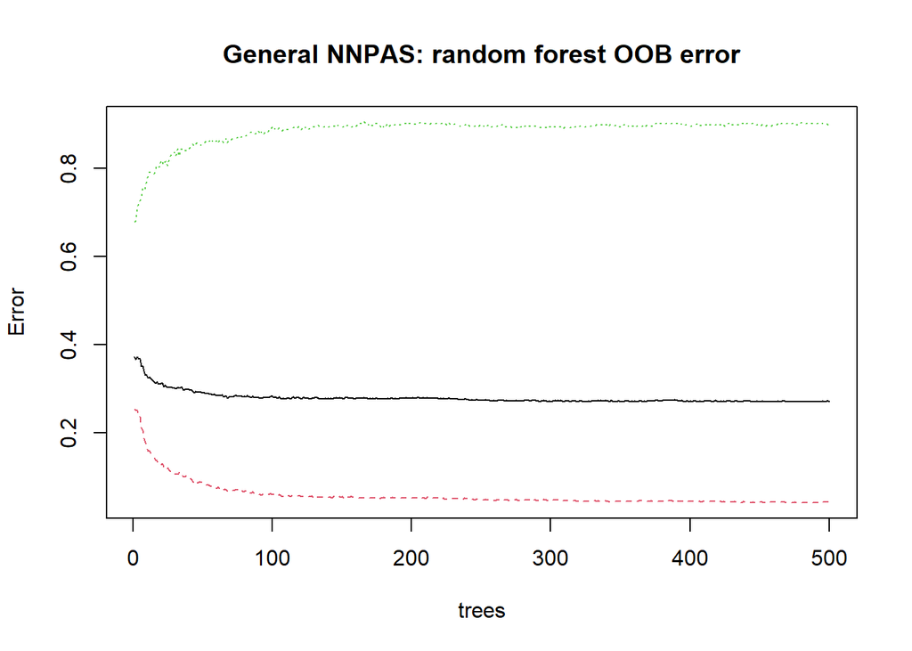

```r
fit_random_forest <- function(df, seed) {
  if (!is.data.frame(df)) {
    stop("fit_random_forest() requires a data.frame. Run Sections 1-3 first.")
  }

  set.seed(seed)

  predictor_matrix <- model.matrix(
    delete.response(terms(tree_formula)),
    data = df
  )

  number_predictors <- max(1L, ncol(predictor_matrix) - 1L)

  randomForest(
    tree_formula,
    data = df,
    ntree = 500,
    mtry = max(1L, floor(sqrt(number_predictors))),
    importance = TRUE,
    proximity = FALSE,
    na.action = na.omit
  )
}

general_rf <- fit_random_forest(general_data, seed = 6101)

plot(
  general_rf,
  main = "General NNPAS: random forest OOB error"
)
```

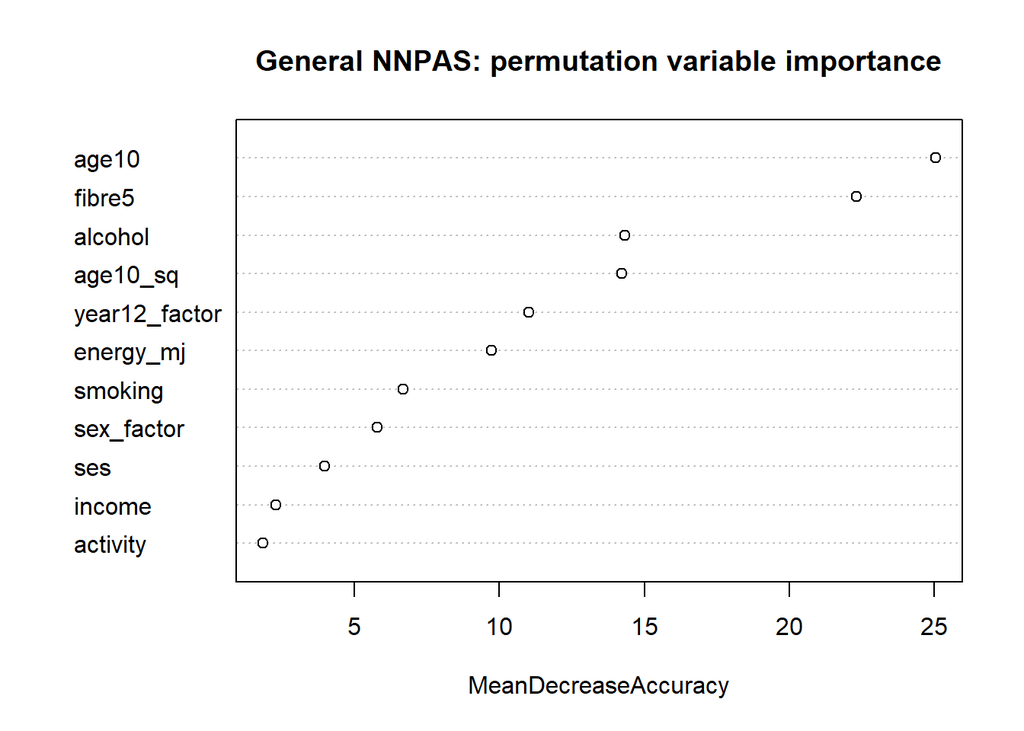

```r
varImpPlot(
  general_rf,
  type = 1,
  main = "General NNPAS: permutation variable importance"
)
```

For the line chart, from up to below, these lines represents the error of Obese, Overall, Not Obese respectively. This figure suggests that the model can easily classify those no-obese participants. However, it missclasified about 90% Obese participants.

The dot chart illustrates the permutation importance of the random forest model. It suggests that age is the most essential variable to the model while physical activity has least contribution.

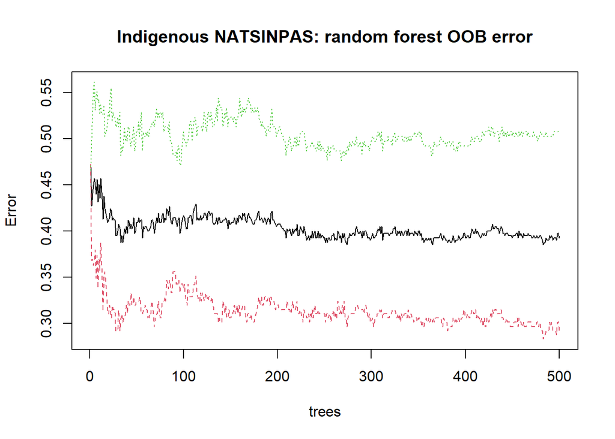

```r
indigenous_rf <- fit_random_forest(indigenous_data, seed = 6102)

plot(
  indigenous_rf,
  main = "Indigenous NATSINPAS: random forest OOB error"
)
```

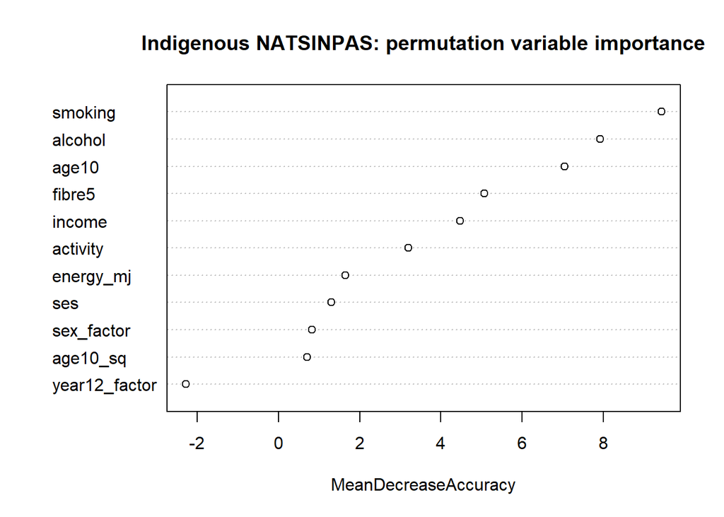

```r
varImpPlot(
  indigenous_rf,
  type = 1,
  main = "Indigenous NATSINPAS: permutation variable importance"
)
```

After researching the indigenous model, the error of Obese has decreased to approximately 50% while the error rate of Overall and No-obese has increased. This states the the model performance has the same result as general but with less accuracy.

The dot chart of indigenous participants shows smoking is the most important variable to the model whereas the year12_factor is the least.

## GAM model fitted

The Generalized Additive Model contains multiple structured penalties by replacing some or all linear effects by smooth functions.

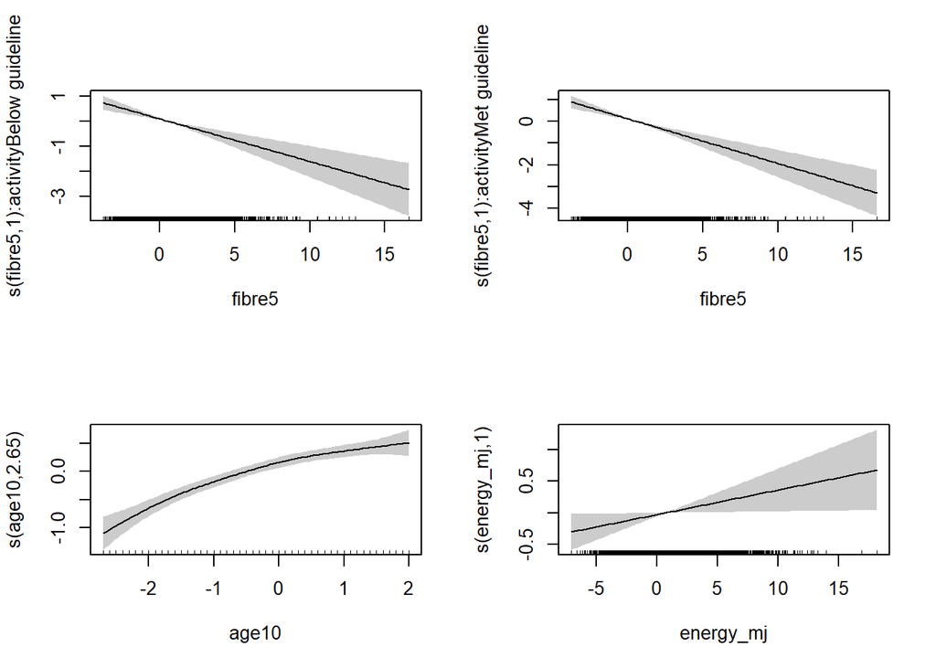

```r
gam_formula <- obese ~
  activity +
  s(fibre5, by = activity, k = 6, bs = "cr") +
  s(age10, k = 6, bs = "cr") +
  s(energy_mj, k = 6, bs = "cr") +
  sex_factor +
  ses +
  income +
  year12_factor +
  smoking +
  alcohol

general_gam <- gam(
  gam_formula,
  data = general_data,
  weights = normalise_weights(general_data$survey_weight),
  family = quasibinomial(),
  method = "REML"
)

indigenous_gam <- gam(
  gam_formula,
  data = indigenous_data,
  weights = normalise_weights(indigenous_data$survey_weight),
  family = quasibinomial(),
  method = "REML"
)

plot(
  general_gam,
  pages = 1,
  shade = TRUE,
  residuals = FALSE,
  scale = 0
)
```

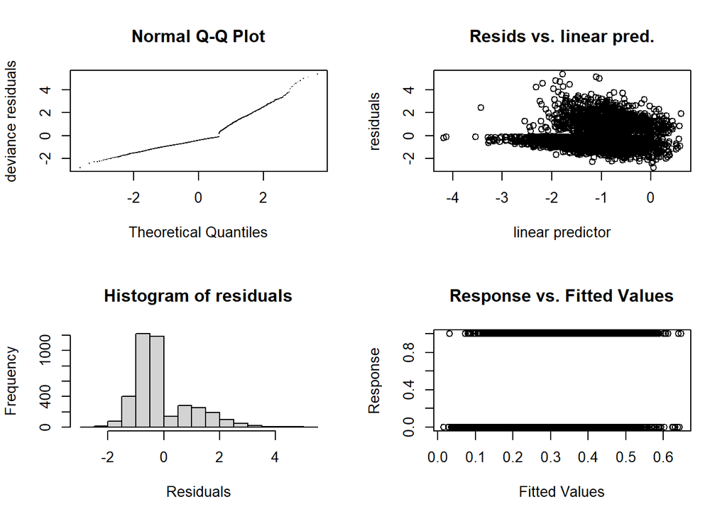

```
##
## Method: REML   Optimizer: outer newton
## full convergence after 9 iterations.
## Gradient range [-0.0005539244,0.0004095774]
## (score 3334.437 & scale 0.9916965).
## Hessian positive definite, eigenvalue range [7.253602e-05,1972].
## Model rank =  32 / 32
##
## Basis dimension (k) checking results. Low p-value (k-index<1) may
## indicate that k is too low, especially if edf is close to k'.
##
##                                     k'  edf k-index p-value
## s(fibre5):activityBelow guideline 5.00 1.00    0.99    0.68
## s(fibre5):activityMet guideline   5.00 1.00    0.99    0.60
## s(age10)                          5.00 2.65    0.99    0.71
## s(energy_mj)                      5.00 1.00    1.00    0.80
```

```r
gam.check(general_gam)
```

For general category, the GAM diagnostics indicated satisfactory model convergence and adequate basis dimensions. Fibre intake showed an approximately linear negative association with the log-odds of obesity in both physical-activity groups. The similarity of the two fibre smooths provided little visual evidence that physical activity substantially modified this association. Age showed a nonlinear positive association with obesity, whereas energy intake had an approximately linear positive association. The GAM model does not follow the normal distribution and it cannot clearly divide the obese participants with those no-obese.

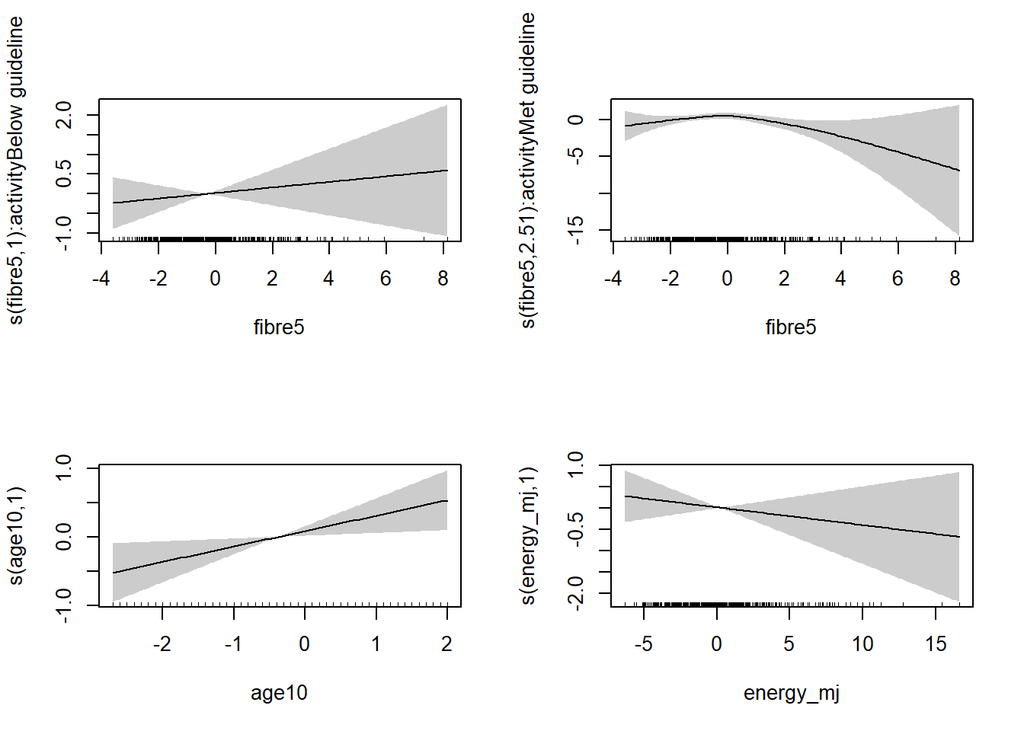

```r
plot(
  indigenous_gam,
  pages = 1,
  shade = TRUE,
  residuals = FALSE,
  scale = 0
)
```

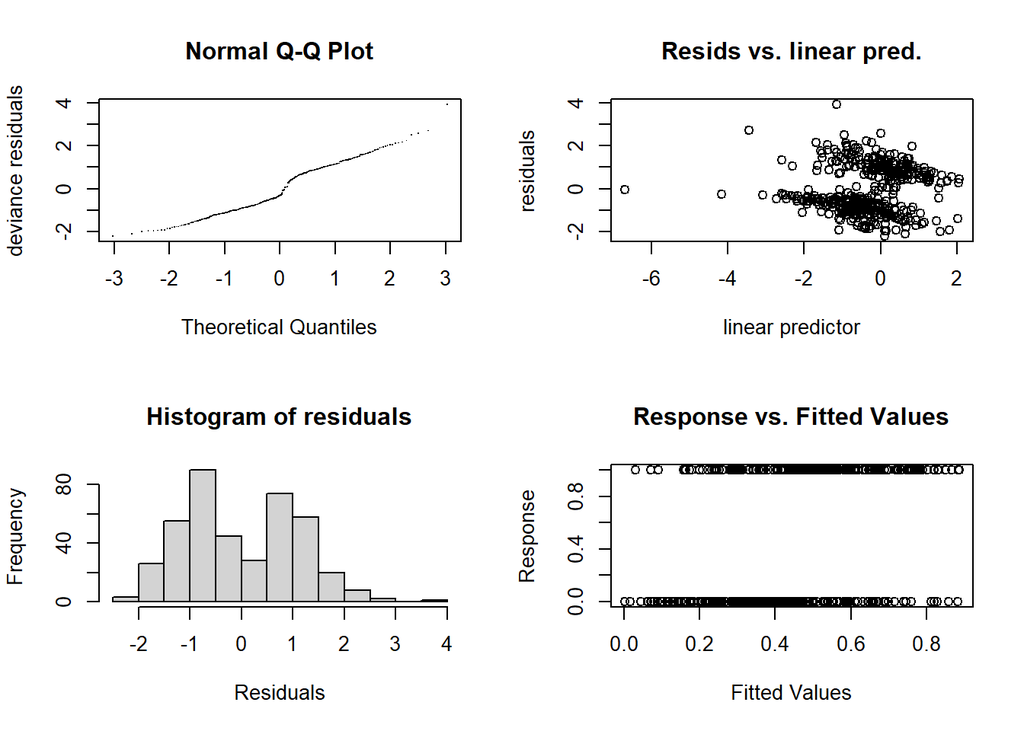

```
##
## Method: REML   Optimizer: outer newton
## full convergence after 12 iterations.
## Gradient range [-3.97516e-05,3.801481e-05]
## (score 333.6687 & scale 0.9608535).
## Hessian positive definite, eigenvalue range [6.961084e-06,197.0017].
## Model rank =  32 / 32
##
## Basis dimension (k) checking results. Low p-value (k-index<1) may
## indicate that k is too low, especially if edf is close to k'.
##
##                                     k'  edf k-index p-value
## s(fibre5):activityBelow guideline 5.00 1.00    1.02    0.66
## s(fibre5):activityMet guideline   5.00 2.51    1.02    0.66
## s(age10)                          5.00 1.00    1.01    0.51
## s(energy_mj)                      5.00 1.00    0.98    0.26
```

```r
gam.check(indigenous_gam)
```

In the Indigenous NATSINPAS sample, the estimated fibre–obesity relationship differed visually by physical-activity status. Among participants below the activity guideline, the fibre smooth was approximately linear and slightly positive. Among those meeting the guideline, the association was nonlinear and became negative at higher fibre intakes. This pattern is consistent with possible effect modification by physical activity. However, the confidence intervals were wide, particularly at high fibre intakes where observations were sparse.

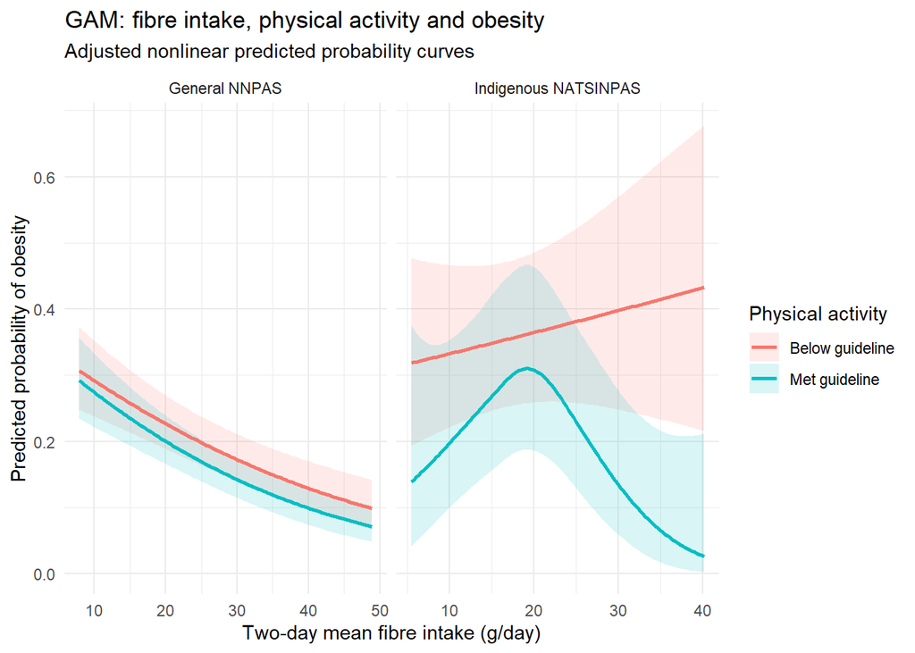

```r
modal_value <- function(x) {
  names(which.max(table(x)))
}

make_gam_prediction_data <- function(model, data, population_name) {
  fibre_sequence <- seq(
    quantile(data$fibre5, 0.02),
    quantile(data$fibre5, 0.98),
    length.out = 120
  )

  prediction_data <- expand.grid(
    fibre5 = fibre_sequence,
    activity = factor(
      c("Below guideline", "Met guideline"),
      levels = levels(data$activity)
    )
  )

  prediction_data$age10 <- weighted.mean(
    data$age10,
    data$survey_weight
  )

  prediction_data$energy_mj <- weighted.mean(
    data$energy_mj,
    data$survey_weight
  )

  prediction_data$sex_factor <- factor(
    modal_value(data$sex_factor),
    levels = levels(data$sex_factor)
  )

  prediction_data$ses <- factor(
    modal_value(data$ses),
    levels = levels(data$ses)
  )

  prediction_data$income <- weighted.mean(
    data$income,
    data$survey_weight
  )

  prediction_data$year12_factor <- factor(
    modal_value(data$year12_factor),
    levels = levels(data$year12_factor)
  )

  prediction_data$smoking <- factor(
    modal_value(data$smoking),
    levels = levels(data$smoking)
  )

  prediction_data$alcohol <- weighted.mean(
    data$alcohol,
    data$survey_weight
  )

  prediction <- predict(
    model,
    newdata = prediction_data,
    type = "link",
    se.fit = TRUE
  )

  prediction_data$Predicted_probability <- plogis(prediction$fit)
  prediction_data$Lower <- plogis(
    prediction$fit - 1.96 * prediction$se.fit
  )
  prediction_data$Upper <- plogis(
    prediction$fit + 1.96 * prediction$se.fit
  )
  prediction_data$Fibre_g_day <- 20 + 5 * prediction_data$fibre5
  prediction_data$Population <- population_name

  prediction_data
}

gam_prediction_data <- bind_rows(
  make_gam_prediction_data(
    general_gam,
    general_data,
    "General NNPAS"
  ),
  make_gam_prediction_data(
    indigenous_gam,
    indigenous_data,
    "Indigenous NATSINPAS"
  )
)

gam_probability_plot <- ggplot(
  gam_prediction_data,
  aes(
    x = Fibre_g_day,
    y = Predicted_probability,
    colour = activity,
    fill = activity
  )
) +
  geom_ribbon(
    aes(ymin = Lower, ymax = Upper),
    alpha = 0.15,
    colour = NA
  ) +
  geom_line(linewidth = 1) +
  facet_wrap(~Population, scales = "free_x") +
  labs(
    title = "GAM: fibre intake, physical activity and obesity",
    subtitle = "Adjusted nonlinear predicted probability curves",
    x = "Two-day mean fibre intake (g/day)",
    y = "Predicted probability of obesity",
    colour = "Physical activity",
    fill = "Physical activity"
  ) +
  theme_minimal()

print(gam_probability_plot)
```

The two plots helps turning the GAM result into adjusted obese predicted probability.In the General NNPAS sample, predicted obesity probability declined with increasing fibre intake in both physical-activity groups. The curves were approximately parallel, providing little evidence of substantial effect modification by physical activity. In the Indigenous NATSINPAS sample, the estimated curves differed more noticeably: among participants meeting the physical-activity guideline, predicted obesity probability declined at higher fibre intakes, whereas it increased slightly among those below the guideline.

## Ten-fold Cross Validation

The Ten-fold Cross Validation is used for testing the goodness of fit for each models.

```r
clip_probability <- function(probability, epsilon = 1e-6) {
  pmin(pmax(as.numeric(probability), epsilon), 1 - epsilon)
}

weighted_auc <- function(outcome, probability, weights) {
  outcome <- as.integer(outcome)
  probability <- as.numeric(probability)
  weights <- as.numeric(weights)

  if (sum(weights[outcome == 1]) == 0 ||
      sum(weights[outcome == 0]) == 0) {
    return(NA_real_)
  }

  probability_table <- data.frame(
    probability = probability,
    positive_weight = weights * outcome,
    negative_weight = weights * (1 - outcome)
  ) %>%
    group_by(probability) %>%
    summarise(
      positive_weight = sum(positive_weight),
      negative_weight = sum(negative_weight),
      .groups = "drop"
    ) %>%
    arrange(probability) %>%
    mutate(
      negative_below = cumsum(negative_weight) - negative_weight
    )

  numerator <- sum(
    probability_table$positive_weight *
      (
        probability_table$negative_below +
          0.5 * probability_table$negative_weight
      )
  )

  denominator <-
    sum(probability_table$positive_weight) *
    sum(probability_table$negative_weight)

  numerator / denominator
}

calculate_metrics <- function(outcome, probability, weights) {
  probability <- clip_probability(probability)

  data.frame(
    AUC = weighted_auc(outcome, probability, weights),
    Brier = weighted.mean(
      (outcome - probability)^2,
      weights
    ),
    Log_loss = weighted.mean(
      -(
        outcome * log(probability) +
          (1 - outcome) * log(1 - probability)
      ),
      weights
    )
  )
}

run_ten_fold_cv <- function(data, population_name, seed) {
  set.seed(seed)

  test_folds <- createFolds(
    data$obesity,
    k = 10,
    list = TRUE,
    returnTrain = FALSE
  )

  fold_results <- vector("list", length(test_folds))

  for (fold_number in seq_along(test_folds)) {
    test_index <- test_folds[[fold_number]]
    train_index <- setdiff(seq_len(nrow(data)), test_index)

    training_data <- data[train_index, , drop = FALSE]
    testing_data <- data[test_index, , drop = FALSE]
    training_data$cv_weight <- normalise_weights(
  training_data$survey_weight
)

    cv_glm <- glm(
      baseline_formula,
      data = training_data,
      weights = cv_weight,
      family = quasibinomial()
    )

    glm_probability <- predict(
      cv_glm,
      newdata = testing_data,
      type = "response"
    )

    cv_tree <- fit_pruned_tree(training_data)$pruned_tree

    tree_probability <- predict(
      cv_tree,
      newdata = testing_data,
      type = "prob"
    )[, "Obese"]

    cv_rf <- fit_random_forest(
      training_data,
      seed = seed + fold_number
    )

    rf_probability <- predict(
      cv_rf,
      newdata = testing_data,
      type = "prob"
    )[, "Obese"]

    cv_gam <- gam(
      gam_formula,
      data = training_data,
      weights = cv_weight,
      family = quasibinomial(),
      method = "REML"
    )

    gam_probability <- predict(
      cv_gam,
      newdata = testing_data,
      type = "response"
    )

    model_probabilities <- list(
      `Weighted GLM benchmark` = glm_probability,
      `Decision tree` = tree_probability,
      `Random forest` = rf_probability,
      GAM = gam_probability
    )

    fold_results[[fold_number]] <- bind_rows(
      lapply(names(model_probabilities), function(model_name) {
        cbind(
          data.frame(
            Population = population_name,
            Fold = fold_number,
            Model = model_name
          ),
          calculate_metrics(
            outcome = testing_data$obese,
            probability = model_probabilities[[model_name]],
            weights = testing_data$survey_weight
          )
        )
      })
    )
  }

  bind_rows(fold_results)
}

general_cv_results <- run_ten_fold_cv(
  general_data,
  population_name = "General NNPAS",
  seed = 8101
)

indigenous_cv_results <- run_ten_fold_cv(
  indigenous_data,
  population_name = "Indigenous NATSINPAS",
  seed = 8102
)

cv_results <- bind_rows(
  general_cv_results,
  indigenous_cv_results
)

cv_summary <- cv_results %>%
  group_by(Population, Model) %>%
  summarise(
    Mean_AUC = mean(AUC, na.rm = TRUE),
    SD_AUC = sd(AUC, na.rm = TRUE),
    Mean_Brier = mean(Brier, na.rm = TRUE),
    SD_Brier = sd(Brier, na.rm = TRUE),
    Mean_log_loss = mean(Log_loss, na.rm = TRUE),
    SD_log_loss = sd(Log_loss, na.rm = TRUE),
    .groups = "drop"
  )

print(cv_summary)
```

```
## # A tibble: 8 × 8
##   Population Model Mean_AUC SD_AUC Mean_Brier SD_Brier Mean_log_loss SD_log_loss
##   <chr>      <chr>    <dbl>  <dbl>      <dbl>    <dbl>         <dbl>       <dbl>
## 1 General N… Deci…    0.511 0.0337      0.191   0.0129         0.569      0.0282
## 2 General N… GAM      0.645 0.0454      0.182   0.0149         0.546      0.0352
## 3 General N… Rand…    0.630 0.0386      0.186   0.0160         0.554      0.0390
## 4 General N… Weig…    0.649 0.0429      0.182   0.0145         0.544      0.0342
## 5 Indigenou… Deci…    0.512 0.101       0.287   0.0514         0.876      0.329
## 6 Indigenou… GAM      0.642 0.0746      0.237   0.0234         0.685      0.0697
## 7 Indigenou… Rand…    0.645 0.0736      0.232   0.0168         0.656      0.0384
## 8 Indigenou… Weig…    0.621 0.0841      0.244   0.0258         0.697      0.0734
```

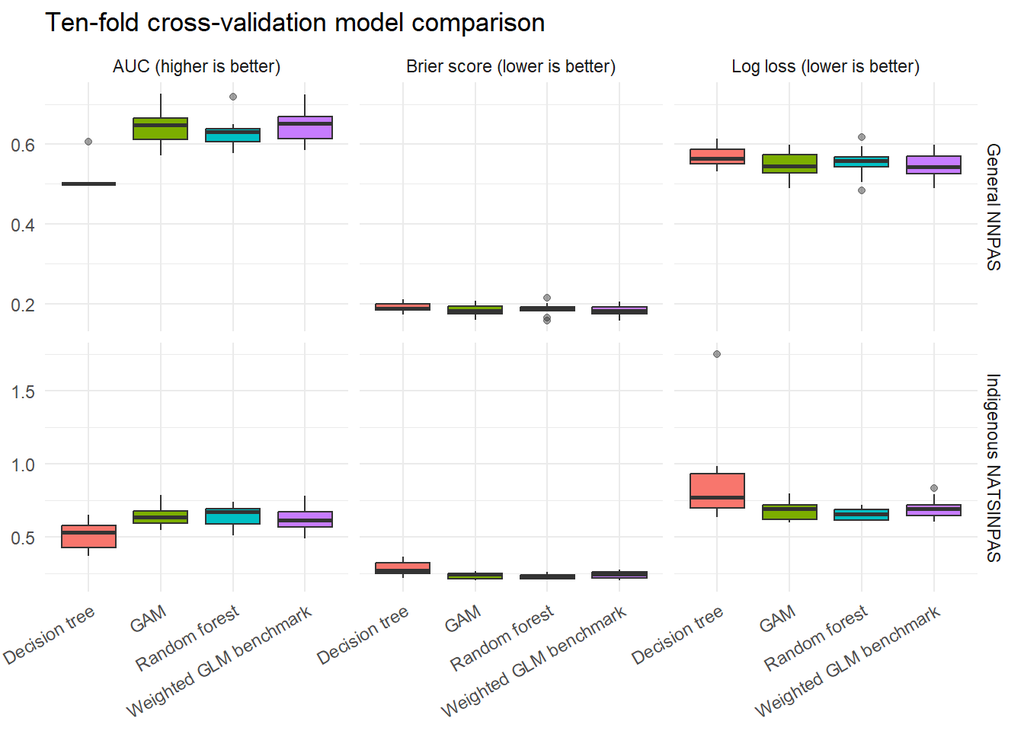

```r
cv_plot_data <- bind_rows(
  cv_results %>%
    transmute(
      Population,
      Fold,
      Model,
      Metric = "AUC (higher is better)",
      Score = AUC
    ),
  cv_results %>%
    transmute(
      Population,
      Fold,
      Model,
      Metric = "Brier score (lower is better)",
      Score = Brier
    ),
  cv_results %>%
    transmute(
      Population,
      Fold,
      Model,
      Metric = "Log loss (lower is better)",
      Score = Log_loss
    )
)

cv_comparison_plot <- ggplot(
  cv_plot_data,
  aes(x = Model, y = Score, fill = Model)
) +
  geom_boxplot(outlier.alpha = 0.45) +
  facet_grid(
    Population ~ Metric,
    scales = "free_y"
  ) +
  labs(
    title = "Ten-fold cross-validation model comparison",
    x = NULL,
    y = NULL
  ) +
  theme_minimal() +
  theme(
    legend.position = "none",
    axis.text.x = element_text(angle = 30, hjust = 1)
  )

print(cv_comparison_plot)
```

Both outputs illustrates the result of comparing different models using 10-fold cross validation. It measures the ability of predicting obese between upon models. According to the result, decision tree has the least predicting performance among all models. GLM and GAM had the strongest and almost identical predictive performance in the General NNPAS sample. In the indigenous model, Random forest has the best performance, with the GAM performing similarly. However, predictive performance was only moderate and varied considerably across folds since all models have AUC less than 0.65.

## conclusion

In conclusion, GLM is is broadly adequate, particularly in the General NNPAS sample. Flexible models do not provide a meaningful improvement in that sample. In the Indigenous NATSINPAS sample, GAM and random forest suggest that some nonlinear or more complex structure may be present, but the improvement over the GLM is modest and uncertain. The GLM should therefore remain the primary inferential model, while GAM and random forest should be presented as sensitivity checks.